# NSRAA Salmon Lake Coho Mark-Recapture

Sara E. Miller

May 2017

# Executive Summary

The population estimate of adult (>410mm MEF) Salmon Lake Coho salmon, based on the Schumacher and Eschmeyer (1943) method, is 3,495 fish with lower and upper 95% confidence intervals of 2,155 fish and 9,236 fish, respectively, computed by a *t* distribution. Based on similiar probabilities of capture, sampling dates 8/24-8/31, 9/7-9/22, 9/27-10/4, 10/13-10/17, and 10/20-10/27 were pooled before model estimation. The Schumacher and Eschmeyer estimation method is the most robust and useful method for multiple censuses of closed populations (Seber 2002).

The population estimate of jack (<410mm MEF) Salmon Lake Coho salmon, based on the Schumacher and Eschmeyer (1943) method, is 872 fish with lower and upper 95% confidence intervals of 151 fish and -232 fish, respectively, computed by a *t* distribution. Based on similiar probabilities of capture, sampling dates 9/7-9/22, 9/27-10/11, and 10/13-10/27 were pooled before model estimation. The Schumacher and Eschmeyer estimation method is the most robust and useful method for multiple censuses of closed populations (Seber 2002).

## Methods

The data for the Schumacher and Eschmeyer estimation method is organized so that each sample date is a strata. ‘Total Catch’ includes sampled carcasses and mortalities. This data is only from samples collected in Salmon Lake. Those samples marked and recaptured in salt water were ignored for this analysis. ‘New Marks’ are numbers of fish given unique Floy tags.

**Table 1:** Salmon Lake coho data organized for the Schumacher and Eschmeyer estimation method.+

| Strata | Sample.Dates | Total.Catch | Recaptures | New.Marks | Cumulative.Marks |
| --- | --- | --- | --- | --- | --- |
| 1 | 2016-08-24 | 5 | 0 | 5 | 0 |
| 2 | 2016-08-31 | 3 | 0 | 3 | 5 |
| 3 | 2016-09-07 | 8 | 0 | 8 | 8 |
| 4 | 2016-09-12 | 6 | 0 | 6 | 16 |
| 5 | 2016-09-16 | 52 | 0 | 52 | 22 |
| 6 | 2016-09-20 | 8 | 0 | 8 | 74 |
| 7 | 2016-09-22 | 31 | 2 | 29 | 82 |
| 8 | 2016-09-27 | 9 | 0 | 9 | 111 |
| 9 | 2016-09-30 | 1 | 1 | 0 | 120 |
| 10 | 2016-10-04 | 65 | 0 | 63 | 120 |
| 11 | 2016-10-07 | 41 | 4 | 37 | 183 |
| 12 | 2016-10-11 | 28 | 4 | 24 | 220 |
| 13 | 2016-10-13 | 88 | 6 | 82 | 244 |
| 14 | 2016-10-17 | 57 | 8 | 48 | 326 |
| 15 | 2016-10-20 | 50 | 3 | 46 | 374 |
| 16 | 2016-10-27 | 47 | 3 | 0 | 420 |
| Total |  | 499 | 31 | 420 |  |

The R package fishmethods was used to estimate the abundance and confidence interval for the Schumacher and Eschmeyer estimation method (Krebs 1989; Nelson 2017; Seber 2002).

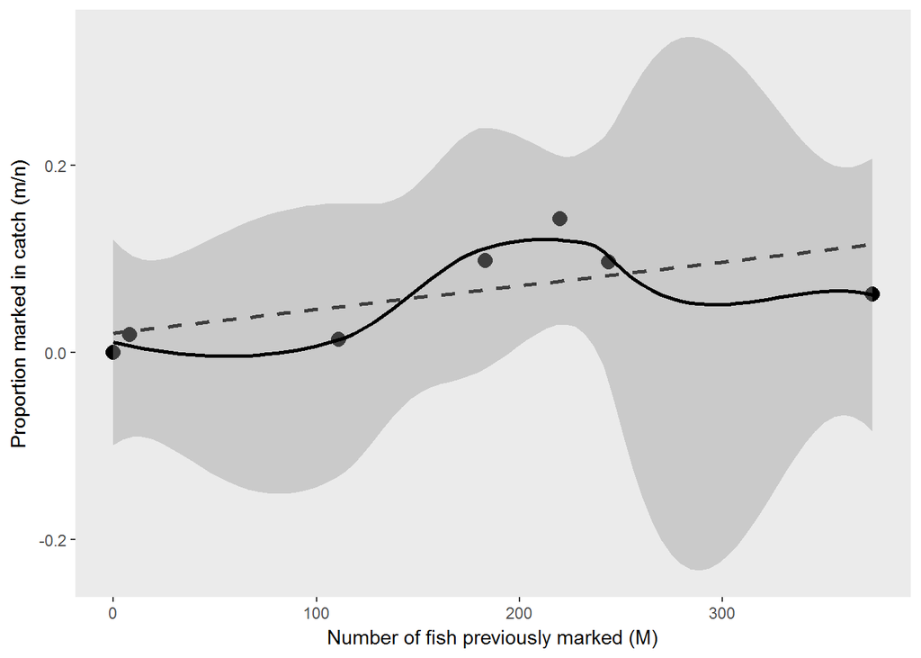

**Figure 1:** A plot of the accumulated number of marked animals (*M*) against the proportion of marked animals in each sample (*m*/*n*). The plot will be linear if the assumptions underlying the method are fulfilled (dotted line). A curvilinear plot (solid line) shows that the assumptions are violated and either the population is not closed or catchability is not constant. The adjusted $R^2$ from the linear regression is 0.29 (p-value=0.123). Although the relationship is curvilienar, there are few datapoints analyzed.

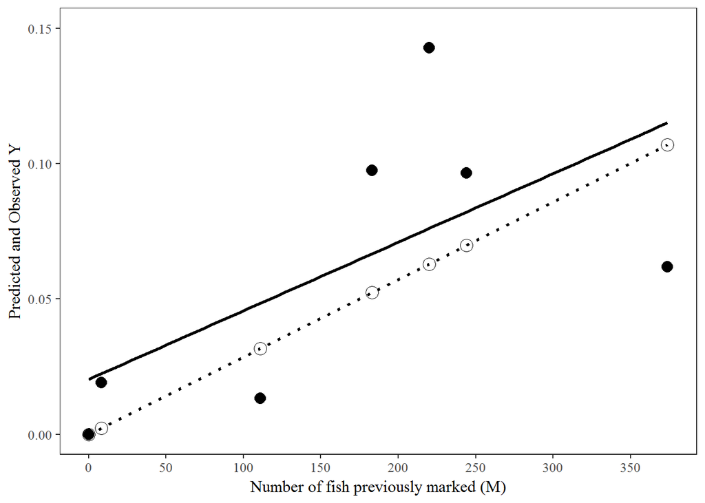

**Figure 2:** A plot of the accumulated number of marked animals (*M*) against the predicted and observed *y*. The open circles and dotted line are the predicted *y*. The predicted *y* is the value of the sum of *m*x*M* divided by the sum of *n*x*M*x*M*, then the calculated value multiplied by the *M* of each strata. The solid circles observed *y*=*m*/*n* and the solid line is the linear fit to the observed values.

**R code for Estimation (adults):**

```r
require(fishmethods)
require(stats)
require(knitr)
require(pander)
#Input data and create coho mark-recapture dataframe
n <- as.numeric(c(8,105,75,41,28,145,97))  #Total Catch
m <- as.numeric(c(0,2,1,4,4,14,6))  #Recaptures
R <- as.numeric(c(8,103,72,37,24,130,46))  #New Marks
M <- c(0, cumsum(R)[-7])
coho <- data.frame(n=n , m = m, R= R, M = as.numeric(M),prop=as.numeric(m/n))
#Schumacher-Eschmeyer method (based on fishmethods package)
x<-as.data.frame(schnabel(catch = n, recaps = m, newmarks = R, alpha=0.05))
N<-round(x[2,1],0)#abundance estimate
invSE<-x[2,2] #inverse standard errors
LCI<-round(x[2,3],0) #lower CI
UCI<-round(x[2,4],0) #upper CI
#Schumacher-Eschmeyer method (based on FSA package)
mr <- mrClosed(M=M,n=n,m=m,method="SchumacherEschmeyer")
abundance<-summary(mr) #abundance estimate
CI<-confint(mr) #confidence interval
#plot(mr,loess=TRUE) #outputs plot
```

**References:**

Krebs, C.J. 1989 Ecological Methodologies. Harper and Row, New York, NY. 745 p.

Nelson, G.A. 2017. fishmethods: Fishery Science Methods and Models in R. https://CRAN.R-project.org/package=fishmethods.

Schumacher, F.X. and R.W. Eschmeyer. 1943. The estimation of fish populations in lakes and ponds. Journal of the Tennessee Academy of Sciences, 18:228-249.

Seber, G.A.F. 2002. The Estimation of Animal Abundance and realted parameters. Second Edition. Blackburn Press, New Jersey. 654 p.